# Colour, Fill, and Shape Palettes

```r
library(ggplot2)
library(ggprism)
library(patchwork)
```

`ggprism` includes colour and fill scales with various palettes that mirror the colour schemes available in GraphPad Prism.

**Disclaimer:** some of these palettes are quite nice, some are pretty ugly and not useful, and most are not colour blind friendly as far as I know (except `palette = "colorblind_safe"`). It would probably be safer to use other colour scales e.g. those in `RColorBrewer` for any serious application or work to be published.

In any case, these scales are used to colour the data elements of ggplots and can be used separately or together with `theme_prism()`. Additionally, a shape scale with 3 palettes is included which is similar to the shapes available in Prism. This vignette outlines how to use `scale_colour_prism()` (or `scale_color_prism()`), `scale_fill_prism()`, and `scale_shape_prism()`.

## Colour scales

First we’ll create a base plot.

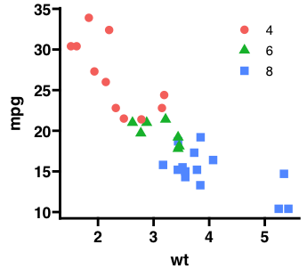

```r
# create a base plot to compare colour scales
base <- ggplot(mtcars, aes(x = wt, y = mpg)) +
  geom_point(aes(colour = factor(cyl), shape = factor(cyl)), size = 3) +
  theme_prism() +
  guides(colour = guide_legend(position = "inside")) +
  theme(legend.position.inside = c(0.8, 0.8))

base
```

`scale_colour_prism()` (US spelling also works) functions pretty much identically to `scale_colour_manual()` from `ggplot2`. The default palette for `scale_colour_prism()` is `"colors"`.

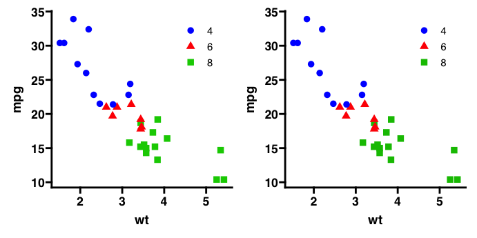

```r
# compare manual colour scale with prism colour scale
p1 <- base + scale_colour_manual(values = c("blue", "red", "green3"))
p2 <- base + scale_colour_prism()

p1 + p2
```

There are several different colour palettes that are built into `scale_colour_prism()`.

```r
# see names and lengths of available scale_colour_prism() palettes
lengths(ggprism_data$colour_palettes)
```

```
#>   autumn_leaves   beer_and_ales black_and_white       blueprint      blueprint2
#>               9               9               9               9               9
#>      blueprint3    candy_bright      candy_soft colorblind_safe          colors
#>               9               9               9               6              20
#>           diazo     earth_tones       evergreen             fir            fir2
#>               9              10               9               9               9
#>            fir3          flames         flames2          floral         floral2
#>               9               9               9              12              12
#>       greenwash         inferno           magma   mustard_field  mustard_field2
#>              10               6               6               9               9
#>   muted_rainbow            neon           ocean          ocean2          ocean3
#>              10               9               9               9               9
#>          office         pastels           pearl          pearl2          plasma
#>               9               9               6               6               6
#>      prism_dark     prism_dark2     prism_light    prism_light2  purple_passion
#>              10              10              10              10               9
#>           quiet          quiet2  shades_of_gray          spring         spring2
#>               9               9               9               9               9
#>   stained_glass  stained_glass2          starry         starry2          summer
#>               9               9               5               5              10
#>    sunny_garden   sunny_garden2   sunny_garden3       the_blues         viridis
#>               9               9               9               9               6
#>  warm_and_sunny    warm_pastels   warm_pastels2           waves          waves2
#>               9               9               9               5               5
#>   winter_bright     winter_soft    wool_muffler   wool_muffler2   wool_muffler3
#>               9               9               9               9               9
```

Using the palettes is simple.

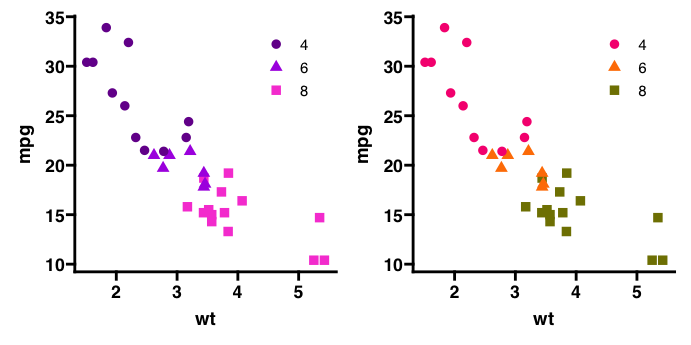

```r
# try out some different colour palettes
p1 <- base + scale_colour_prism(palette = "purple_passion")
p2 <- base + scale_colour_prism(palette = "candy_bright")

p1 + p2
```

You can preview a single palette using the `preview_theme()` function. It shows a sample plot with the colour scale applied (as well as `scale_fill_prism()` and `theme_prism()`). See [this page](https://csdaw.github.io/ggprism/articles/web-only/palettes.html) for images of most available colour palettes.

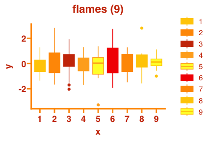

```r
preview_theme("flames")
```

## Fill scales

First we’ll create a base plot.

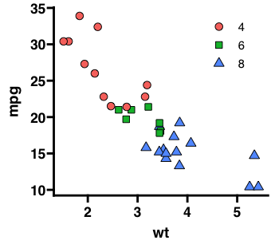

```r
# create a base plot to compare fill scales
base <- ggplot(mtcars, aes(x = wt, y = mpg)) +
  geom_point(aes(fill = factor(cyl), shape = factor(cyl)), size = 3) +
  theme_prism() +
  guides(fill = guide_legend(position = "inside"),
         shape = guide_legend(position = "inside")) +
  theme(legend.position.inside = c(0.8, 0.8)) +
  scale_shape_prism(palette = "filled")

base
```

`scale_fill_prism()` functions pretty much identically to `scale_fill_manual()` from `ggplot2`. The default palette for `scale_fill_prism()` is `"colors"`.

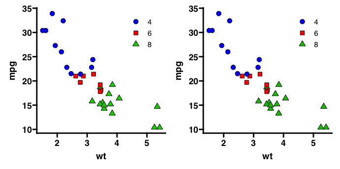

```r
# compare manual fill scale with prism fill scale
p1 <- base + scale_fill_manual(values = c("blue", "red", "green3"))
p2 <- base + scale_fill_prism()

p1 + p2
```

There are several different fill palettes that are built into `scale_fill_prism()`.

```r
# see names and lengths of available scale_fill_prism() palettes
lengths(ggprism_data$fill_palettes)
```

```
#>   autumn_leaves   beer_and_ales black_and_white       blueprint    candy_bright
#>               9               9               9               9               9
#>      candy_soft colorblind_safe          colors           diazo     earth_tones
#>               9               6              20               9              10
#>       evergreen             fir          flames          floral       greenwash
#>               9               9               9              12              10
#>         inferno           magma   mustard_field   muted_rainbow            neon
#>               6               6               9              10               9
#>           ocean          office         pastels           pearl          plasma
#>               9               9               9               6               6
#>      prism_dark     prism_light  purple_passion           quiet  shades_of_gray
#>              10              10               9               9               9
#>          spring   stained_glass          starry          summer    sunny_garden
#>               9               9               5              10               9
#>       the_blues         viridis  warm_and_sunny warm_and_sunny2    warm_pastels
#>               9               6               9               9               9
#>           waves   winter_bright  winter_bright2     winter_soft    wool_muffler
#>               5               9               9               9               9
```

Using the palettes is simple.

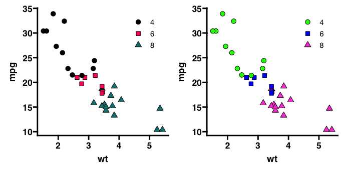

```r
# try out some different fill palettes
p1 <- base + scale_fill_prism(palette = "colorblind_safe")
p2 <- base + scale_fill_prism(palette = "neon")

p1 + p2
```

You can preview a single palette using the `preview_theme()` function. It shows a sample plot with the colour scale applied (as well as `scale_colour_prism()` and `theme_prism()`). See [this page](https://csdaw.github.io/ggprism/articles/web-only/palettes.html) for images of most available fill palettes.

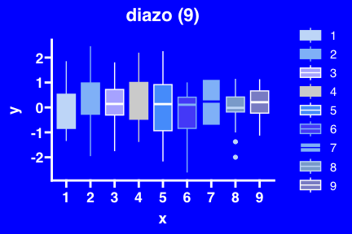

```r
preview_theme("diazo")
```

## Shape scales

The order of shapes used in GraphPad Prism is slightly different to `ggplot2`, hence 3 different shape palettes are included in the `ggprism` function `scale_shape_prism()`.

We can see the names and lengths of these shape palettes. Naturally, `"default"` is the default palette and does not include any shape with a fill. The `"filled"` palette should be used when you also want to use a fill scale, as the first 5 symbols have a fill. The `"complete"` palette symbols 5-9 have a fill.

```r
# see names and lengths of available scale_shape_prism() palettes
lapply(ggprism_data$shape_palettes, nrow)
```

```
#> $complete
#> [1] 14
#>
#> $default
#> [1] 9
#>
#> $filled
#> [1] 10
```

We can also define a function to see all the shapes in a specific palette.

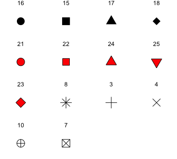

```r
# define a function for convenience
show_shapes <- function(palette) {
  df_shapes <- ggprism_data$shape_palettes[[palette]][, -1]
  df_shapes$pch_f <- factor(df_shapes$pch, levels = df_shapes$pch)

  ggplot(df_shapes, aes(x = 0, y = 0, shape = pch)) +
    geom_point(aes(shape = pch), size = 5, fill = 'red') +
    scale_shape_identity() +
    facet_wrap(~ pch_f) +
    theme_void()
}

# show the shapes in the palette "complete"
show_shapes("complete")
```

We’ll define a base plot to see `scale_shape_prism()` in action.

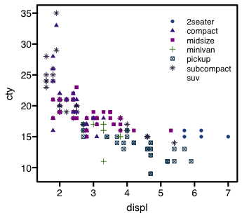

```r
# create a base plot to compare shape scales
base <- ggplot(mpg, aes(x = displ, y = cty)) +
  geom_point(aes(colour = class, fill = class, shape = class)) +
  theme_prism(base_size = 11, base_fontface = "plain", border = TRUE) +
  guides(colour = guide_legend(position = "inside"),
         fill = guide_legend(position = "inside"),
         shape = guide_legend(position = "inside")) +
  theme(plot.subtitle = element_text(face = "bold"),
        legend.position.inside = c(0.8, 0.75),
        legend.key.height = unit(10, "pt")) +
  coord_cartesian(clip = "off") +
  scale_colour_prism(palette = "floral") +
  scale_fill_prism(palette = "floral")

base
```

Then we’ll compare the 3 shape palettes to the `ggplot2` base plot.

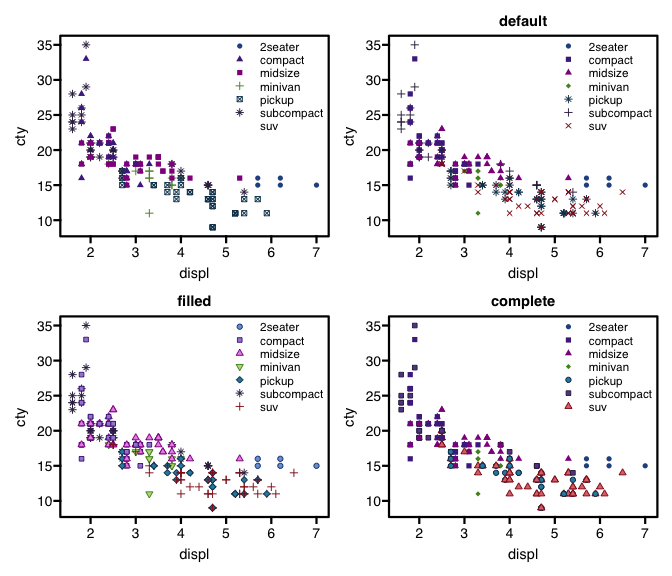

```r
# compare shape scales
p1 <- base
p2 <- base + scale_shape_prism(palette = "default") +
  labs(subtitle = "default")
p3 <- base + scale_shape_prism(palette = "filled") +
  labs(subtitle = "filled")
p4 <- base + scale_shape_prism(palette = "complete") +
  labs(subtitle = "complete")

(p1 + p2) / (p3 + p4)
```